# Model Spesifications

Atakan_Akgun, Aylin Karapanar

2026-01-14

```r
# Essential libraries
library(corrplot)
library(ggeffects)
library(ggplot2)
library(DHARMa)
library(glmmTMB)
library(dplyr)
library(lubridate)
library(emmeans)
library(tidyverse)
library(performance)
library(sjPlot)
```

## 1. Data Import and Preparation

```r
df <- read.csv("./Simulated Data/Mock_Mosquito_MixedEffects_w_slopes_Dataset.csv")
df$Trap_type = factor(df$Trap_type)
df$Mosquito_species = factor(df$Mosquito_species)
```

```r
head(df)
```

|  | City | Site | Sampling_date | Country | Location.Site | Month | Season | Green_level | Green_area_coverage | Blue_area_coverage | Temperature | Relative_humidity | Wind_speed_10m | Trap_type | season_multiplier | Host_abundance | Predator_abundance | Mosquito_species | Mosquito_abundance | Biodiversity_index |
| --- | --- | --- | --- | --- | --- | --- | --- | --- | --- | --- | --- | --- | --- | --- | --- | --- | --- | --- | --- | --- |
| 1 | Utrecht | Site_1 | 2024-01-01 | Netherlands | 1 | 1 | Winter | 2 | 47.38746 | 13.73134 | 6.47 | 72.94 | 6.82 | Light_CO2 | 0.7 | 43 | 83 | Aedes aegypti | 19 | 1.004975 |
| 2 | Utrecht | Site_1 | 2024-01-01 | Netherlands | 1 | 1 | Winter | 2 | 47.38746 | 13.73134 | 6.47 | 72.94 | 6.82 | Light_CO2 | 0.7 | 36 | 78 | Aedes albopictus | 6 | 1.004975 |
| 3 | Utrecht | Site_1 | 2024-01-01 | Netherlands | 1 | 1 | Winter | 2 | 47.38746 | 13.73134 | 6.47 | 72.94 | 6.82 | Light_CO2 | 0.7 | 38 | 78 | Anopheles gambiae | 13 | 1.004975 |
| 4 | Nijmegen | Site_1 | 2024-01-01 | Netherlands | 1 | 1 | Winter | 2 | 63.74675 | 12.42247 | 3.68 | 71.88 | 4.49 | Light_CO2 | 0.7 | 37 | 70 | Culex quinquefasciatus | 6 | 1.283025 |
| 5 | Nijmegen | Site_1 | 2024-01-01 | Netherlands | 1 | 1 | Winter | 2 | 63.74675 | 12.42247 | 3.68 | 71.88 | 4.49 | Light_CO2 | 0.7 | 33 | 92 | Anopheles gambiae | 5 | 1.283025 |
| 6 | Nijmegen | Site_1 | 2024-01-01 | Netherlands | 1 | 1 | Winter | 2 | 63.74675 | 12.42247 | 3.68 | 71.88 | 4.49 | Light_CO2 | 0.7 | 43 | 78 | Aedes aegypti | 22 | 1.283025 |

## 2. Model Specification

### Defining Random Effects

We start by first defining the random effects part. There are two random effects defined in our model, one for the nested structure in our data and the other for the mosquito species. By defining random intercepts in m1 model, we assume that different cities have different baseline abundance levels, different sites within the same city have different baseline abundance, and different mosquito species have different baseline abundance levels. However, the slopes remain consistent meaning all cities and species respond to green coverage the same way.

```r
m1_baseline <- glmmTMB(
  Mosquito_abundance ~ Green_area_coverage * Trap_type +
                       Temperature * Relative_humidity +
                       Host_abundance * Predator_abundance +
                       Blue_area_coverage +
                       factor(Month) +
                       (1 | City / Location.Site) +      # nested random effects
                       (1 | Mosquito_species),           # random intercept by species
  family = nbinom2(),
  data = df,
  REML = TRUE
)

summary(m1_baseline)
```

```
 Family: nbinom2  ( log )
Formula:          Mosquito_abundance ~ Green_area_coverage * Trap_type + Temperature *
    Relative_humidity + Host_abundance * Predator_abundance +
    Blue_area_coverage + factor(Month) + (1 | City/Location.Site) +
    (1 | Mosquito_species)
Data: df

      AIC       BIC    logLik -2*log(L)  df.resid
  16838.7   16987.5   -8393.4   16786.7      2227

Random effects:

Conditional model:
 Groups             Name        Variance Std.Dev.
 Location.Site:City (Intercept) 0.16124  0.4015
 City               (Intercept) 0.06303  0.2511
 Mosquito_species   (Intercept) 0.13456  0.3668
Number of obs: 2253, groups:  Location.Site:City, 54; City, 6; Mosquito_species, 5

Dispersion parameter for nbinom2 family (): 1.92

Conditional model:
                                         Estimate Std. Error z value Pr(>|z|)
(Intercept)                            -1.923e+00  9.002e-01  -2.136 0.032685 *
Green_area_coverage                     1.254e-02  2.271e-03   5.520 3.38e-08 ***
Trap_typeLight_CO2                      1.317e-01  7.571e-02   1.739 0.081984 .
Temperature                             7.375e-02  3.774e-02   1.954 0.050719 .
Relative_humidity                       4.102e-02  9.240e-03   4.439 9.03e-06 ***
Host_abundance                          9.605e-06  1.164e-02   0.001 0.999342
Predator_abundance                     -1.066e-02  7.705e-03  -1.384 0.166387
Blue_area_coverage                      1.945e-03  4.394e-03   0.443 0.657956
factor(Month)2                          1.347e-01  8.679e-02   1.552 0.120573
factor(Month)3                          2.217e-01  9.481e-02   2.338 0.019366 *
factor(Month)4                          1.944e-01  1.064e-01   1.827 0.067742 .
factor(Month)5                          1.565e-01  1.227e-01   1.275 0.202143
factor(Month)6                          2.652e-01  1.278e-01   2.076 0.037924 *
factor(Month)7                          2.259e-01  1.240e-01   1.822 0.068454 .
factor(Month)8                          2.925e-01  1.064e-01   2.750 0.005964 **
factor(Month)9                          1.526e-01  9.350e-02   1.632 0.102600
factor(Month)10                         1.835e-01  8.487e-02   2.162 0.030589 *
factor(Month)11                         6.785e-02  8.376e-02   0.810 0.417857
factor(Month)12                         1.317e-01  8.478e-02   1.554 0.120177
Green_area_coverage:Trap_typeLight_CO2  4.561e-03  1.236e-03   3.691 0.000223 ***
Temperature:Relative_humidity          -5.587e-04  4.962e-04  -1.126 0.260206
Host_abundance:Predator_abundance       2.387e-04  1.638e-04   1.457 0.145092
---
Signif. codes:  0 ‘***’ 0.001 ‘**’ 0.01 ‘*’ 0.05 ‘.’ 0.1 ‘ ’ 1
```

```r
baseline_aic <- AIC(m1_baseline)
cat("Baseline AIC:", baseline_aic, "\n")
```

```
Baseline AIC: 16838.75
```

In the second model, we consider random slopes for green levels in the cities, meaning that the effect of urban green differs per city.

```r
m2_city_green <- glmmTMB(
  Mosquito_abundance ~ Green_area_coverage * Trap_type +
                       Temperature * Relative_humidity +
                       Host_abundance * Predator_abundance +
                       Blue_area_coverage +
                       factor(Month) +
                      (1 + Green_area_coverage | City) +          # City random intercept + slope
                      (1 | Location.Site:City) +
                      (1 | Mosquito_species),
  family = nbinom2(),
  data = df,
  REML =TRUE
)


# Check convergence
check_convergence(m2_city_green)
```

```
[1] TRUE
```

```r
m2_city_green$sdr$pdHess
```

```
[1] TRUE
```

```r
cat("AIC difference:", AIC(m2_city_green) - baseline_aic, "\n")
```

```
AIC difference: -16.5516
```

```r
lrt_m2 <- anova(m1_baseline, m2_city_green)$Chisq[2]
lrt_m2
```

```
[1] 20.5516
```

```r
p_m2 <- 0.5 * pchisq(lrt_m2, df = 2, lower.tail = FALSE) +
           0.5 * pchisq(lrt_m2, df = 1, lower.tail = FALSE)
cat("p-value:", p_m2, "\n")
```

```
p-value: 2.013074e-05
```

AIC difference is negative and the $H_0: \text{Cities do not differ in how urban green level affects mosquito abundance}$ is rejected (p<0.05), the random slope of urban green level is significant.

```r
m3_city_temp <- glmmTMB(
  Mosquito_abundance ~ Green_area_coverage * Trap_type +
                       Temperature * Relative_humidity +
                       Host_abundance * Predator_abundance +
                       Blue_area_coverage +
                       factor(Month) +
                      (1 + Temperature | City) +
                      (1 | Location.Site:City) +
                      (1 | Mosquito_species),
  family = nbinom2(),
  data = df,
  REML = TRUE
)

# Check convergence
check_convergence(m3_city_temp)
```

```
[1] FALSE
```

```r
m3_city_temp$sdr$pdHess
```

```
[1] TRUE
```

```r
cat("AIC difference:", AIC(m3_city_temp) - baseline_aic, "\n")
```

```
AIC difference: -0.7565843
```

```r
lrt_m3 <- anova(m1_baseline, m3_city_temp)$Chisq[2]
lrt_m3
```

```
[1] 4.756584
```

```r
p_m3 <- 0.5 * pchisq(lrt_m3, df = 2, lower.tail = FALSE) +
        0.5 * pchisq(lrt_m3, df = 1, lower.tail = FALSE)
cat("p-value for Temp slope:", p_m3, "\n")
```

```
p-value for Temp slope: 0.06094759
```

```r
m4_both_slopes <- glmmTMB(
  Mosquito_abundance ~ Green_area_coverage * Trap_type +
                       Temperature * Relative_humidity +
                       Host_abundance * Predator_abundance +
                       Blue_area_coverage +
                       factor(Month) +
                       (1 + Green_area_coverage + Temperature | City) +
                       (1 | Location.Site:City) +
                       (1 | Mosquito_species),
  family = nbinom2(),
  data = df,
  REML = TRUE
)

# Check convergence
check_convergence(m4_both_slopes)
```

```
[1] FALSE
```

```r
m4_both_slopes$sdr$pdHess
```

```
[1] FALSE
```

```r
summary(m4_both_slopes)
```

```
 Family: nbinom2  ( log )
Formula:          Mosquito_abundance ~ Green_area_coverage * Trap_type + Temperature *
    Relative_humidity + Host_abundance * Predator_abundance +
    Blue_area_coverage + factor(Month) + (1 + Green_area_coverage +
    Temperature | City) + (1 | Location.Site:City) + (1 | Mosquito_species)
Data: df

      AIC       BIC    logLik -2*log(L)  df.resid
       NA        NA        NA        NA      2222

Random effects:

Conditional model:
 Groups             Name                Variance  Std.Dev. Corr
 City               (Intercept)         1.985e-01 0.445574
                    Green_area_coverage 9.899e-05 0.009949 -0.70
                    Temperature         7.353e-05 0.008575 -0.49 -0.28
 Location.Site:City (Intercept)         7.884e-02 0.280788
 Mosquito_species   (Intercept)         1.340e-01 0.366059
Number of obs: 2253, groups:  City, 6; Location.Site:City, 54; Mosquito_species, 5

Dispersion parameter for nbinom2 family (): 1.92

Conditional model:
                                         Estimate Std. Error z value Pr(>|z|)
(Intercept)                            -2.2141937  0.9257657  -2.392 0.016769 *
Green_area_coverage                     0.0128099  0.0044489   2.879 0.003985 **
Trap_typeLight_CO2                      0.1329878  0.0757391   1.756 0.079111 .
Temperature                             0.0828564  0.0387759   2.137 0.032614 *
Relative_humidity                       0.0437056  0.0096455   4.531 5.87e-06 ***
Host_abundance                          0.0034733  0.0115953   0.300 0.764526
Predator_abundance                     -0.0084670  0.0076748  -1.103 0.269932
Blue_area_coverage                     -0.0004606  0.0032804  -0.140 0.888340
factor(Month)2                          0.1475689  0.0868924   1.698 0.089452 .
factor(Month)3                          0.2367109  0.0947285   2.499 0.012460 *
factor(Month)4                          0.2241434  0.1068201   2.098 0.035876 *
factor(Month)5                          0.1837047  0.1228047   1.496 0.134677
factor(Month)6                          0.2955854  0.1272241   2.323 0.020161 *
factor(Month)7                          0.2661895  0.1247597   2.134 0.032874 *
factor(Month)8                          0.3174874  0.1065868   2.979 0.002895 **
factor(Month)9                          0.1728402  0.0937671   1.843 0.065286 .
factor(Month)10                         0.1976153  0.0850070   2.325 0.020088 *
factor(Month)11                         0.0694093  0.0837820   0.828 0.407415
factor(Month)12                         0.1254302  0.0852061   1.472 0.140999
Green_area_coverage:Trap_typeLight_CO2  0.0045795  0.0012373   3.701 0.000215 ***
Temperature:Relative_humidity          -0.0007220  0.0005182  -1.393 0.163536
Host_abundance:Predator_abundance       0.0001907  0.0001631   1.169 0.242248
---
Signif. codes:  0 ‘***’ 0.001 ‘**’ 0.01 ‘*’ 0.05 ‘.’ 0.1 ‘ ’ 1
```

```r
# Compare m2 -> m4 (does adding temperature slope to m2 improve fit?)
lrt_m2_m4 <- anova(m2_city_green, m4_both_slopes)$Chisq[2]
cat("LRT stat (m2 -> m4):", lrt_m2_m4, "\n")
```

```
LRT stat (m2 -> m4): NA
```

```r
p_m2_m4 <- 0.5 * pchisq(lrt_m2_m4, df = 2, lower.tail = FALSE) +
           0.5 * pchisq(lrt_m2_m4, df = 1, lower.tail = FALSE)
cat("p-value (m2 -> m4):", p_m2_m4, "\n")
```

```
p-value (m2 -> m4): NA
```

```r
# Compare m3 -> m4 (does adding Green slope to m3 improve fit?)
lrt_m3_m4 <- anova(m3_city_temp, m4_both_slopes)$Chisq[2]
cat("LRT stat (m3 -> m4):", lrt_m3_m4, "\n")
```

```
LRT stat (m3 -> m4): NA
```

```r
p_m3_m4 <- 0.5 * pchisq(lrt_m3_m4, df = 2, lower.tail = FALSE) +
           0.5 * pchisq(lrt_m3_m4, df = 1, lower.tail = FALSE)
cat("p-value (m3 -> m4):", p_m3_m4, "\n")
```

```
p-value (m3 -> m4): NA
```

```r
# Compare all models by AIC
models <- list(m1_baseline = m1_baseline, m2 = m2_city_green, m3 = m3_city_temp, m4 = m4_both_slopes)
aic_tab <- data.frame(
  model = names(models),
  AIC = sapply(models, AIC),
  pdHess = sapply(models, function(m) { if (is.null(m$sdr)) NA else m$sdr$pdHess })
)
aic_tab <- aic_tab %>% arrange(AIC)
print(aic_tab)
```

|  | model | AIC | pdHess |
| --- | --- | --- | --- |
| m2 | m2 | 16822.20 | TRUE |
| m3 | m3 | 16837.99 | TRUE |
| m1_baseline | m1_baseline | 16838.75 | TRUE |
| m4 | m4 | NA | FALSE |

Across the models tested, the lowest AIC value was tested was achieved by model 2, for the remainder of the model selection procedure we will use the random effects defined in model 2. Now, we will focus on getting a more parsimonious fixed effects part by removing interaction terms in a step wise manner.

```r
m_full <- glmmTMB(
  Mosquito_abundance ~ Green_area_coverage * Trap_type +
                       Temperature * Relative_humidity +
                       Host_abundance * Predator_abundance +
                       Blue_area_coverage +
                       factor(Month) +
                       (1 + Green_area_coverage | City) +          # City random intercept + slope
                      (1 | Location.Site:City) +
                      (1 | Mosquito_species),
  family = nbinom2(),
  data = df,
  REML = FALSE  # ML for fixed effects comparison
)

summary(m_full)
```

```
 Family: nbinom2  ( log )
Formula:          Mosquito_abundance ~ Green_area_coverage * Trap_type + Temperature *
    Relative_humidity + Host_abundance * Predator_abundance +
    Blue_area_coverage + factor(Month) + (1 + Green_area_coverage |
    City) + (1 | Location.Site:City) + (1 | Mosquito_species)
Data: df

      AIC       BIC    logLik -2*log(L)  df.resid
  16677.7   16837.9   -8310.9   16621.7      2225

Random effects:

Conditional model:
 Groups             Name                Variance  Std.Dev. Corr
 City               (Intercept)         1.190e-01 0.34500
                    Green_area_coverage 8.742e-05 0.00935  -0.90
 Location.Site:City (Intercept)         7.877e-02 0.28066
 Mosquito_species   (Intercept)         1.126e-01 0.33551
Number of obs: 2253, groups:  City, 6; Location.Site:City, 54; Mosquito_species, 5

Dispersion parameter for nbinom2 family (): 1.93

Conditional model:
                                         Estimate Std. Error z value Pr(>|z|)
(Intercept)                            -1.8972007  0.9755665  -1.945 0.051809 .
Green_area_coverage                     0.0126848  0.0042262   3.001 0.002687 **
Trap_typeLight_CO2                      0.1318219  0.0755046   1.746 0.080832 .
Temperature                             0.0681068  0.0382451   1.781 0.074945 .
Relative_humidity                       0.0398077  0.0094049   4.233 2.31e-05 ***
Host_abundance                          0.0026942  0.0130070   0.207 0.835903
Predator_abundance                     -0.0089420  0.0085649  -1.044 0.296474
Blue_area_coverage                     -0.0007221  0.0032995  -0.219 0.826775
factor(Month)2                          0.1352445  0.0864289   1.565 0.117628
factor(Month)3                          0.2243862  0.0942451   2.381 0.017271 *
factor(Month)4                          0.2020812  0.1056172   1.913 0.055705 .
factor(Month)5                          0.1660476  0.1216576   1.365 0.172292
factor(Month)6                          0.2783381  0.1265026   2.200 0.027789 *
factor(Month)7                          0.2416226  0.1228294   1.967 0.049167 *
factor(Month)8                          0.2997455  0.1055584   2.840 0.004517 **
factor(Month)9                          0.1548004  0.0929567   1.665 0.095854 .
factor(Month)10                         0.1852134  0.0845577   2.190 0.028497 *
factor(Month)11                         0.0677827  0.0834608   0.812 0.416705
factor(Month)12                         0.1312440  0.0845911   1.552 0.120779
Green_area_coverage:Trap_typeLight_CO2  0.0046125  0.0012325   3.742 0.000182 ***
Temperature:Relative_humidity          -0.0004983  0.0005085  -0.980 0.327106
Host_abundance:Predator_abundance       0.0002029  0.0001876   1.081 0.279564
---
Signif. codes:  0 ‘***’ 0.001 ‘**’ 0.01 ‘*’ 0.05 ‘.’ 0.1 ‘ ’ 1
```

We start by removing the least significant interaction term which is Temperature:Relative_humidity .

```r
m_wo_temp_hum <- glmmTMB(
  Mosquito_abundance ~ Green_area_coverage * Trap_type +
                       Temperature + Relative_humidity +
                       Host_abundance * Predator_abundance +
                       Blue_area_coverage +
                       factor(Month) +
                       (1 + Green_area_coverage | City) +          # City random intercept + slope
                      (1 | Location.Site:City) +
                      (1 | Mosquito_species),
  family = nbinom2(),
  data = df,
  REML = FALSE  # ML for fixed effects comparison
)

summary(m_wo_temp_hum)
```

```
 Family: nbinom2  ( log )
Formula:          Mosquito_abundance ~ Green_area_coverage * Trap_type + Temperature +
    Relative_humidity + Host_abundance * Predator_abundance +
    Blue_area_coverage + factor(Month) + (1 + Green_area_coverage |
    City) + (1 | Location.Site:City) + (1 | Mosquito_species)
Data: df

      AIC       BIC    logLik -2*log(L)  df.resid
  16676.8   16831.2   -8311.4   16622.8      2226

Random effects:

Conditional model:
 Groups             Name                Variance  Std.Dev. Corr
 City               (Intercept)         0.1177399 0.343132
                    Green_area_coverage 0.0000874 0.009349 -0.90
 Location.Site:City (Intercept)         0.0778270 0.278975
 Mosquito_species   (Intercept)         0.1123605 0.335202
Number of obs: 2253, groups:  City, 6; Location.Site:City, 54; Mosquito_species, 5

Dispersion parameter for nbinom2 family (): 1.93

Conditional model:
                                         Estimate Std. Error z value Pr(>|z|)
(Intercept)                            -1.2771568  0.6923647  -1.845 0.065091 .
Green_area_coverage                     0.0126626  0.0042227   2.999 0.002711 **
Trap_typeLight_CO2                      0.1310218  0.0755164   1.735 0.082739 .
Temperature                             0.0310719  0.0079576   3.905 9.44e-05 ***
Relative_humidity                       0.0311882  0.0034109   9.144  < 2e-16 ***
Host_abundance                          0.0031953  0.0129987   0.246 0.805824
Predator_abundance                     -0.0086072  0.0085601  -1.006 0.314656
Blue_area_coverage                     -0.0006782  0.0032827  -0.207 0.836315
factor(Month)2                          0.1333389  0.0864385   1.543 0.122931
factor(Month)3                          0.2255608  0.0942611   2.393 0.016714 *
factor(Month)4                          0.2078533  0.1054546   1.971 0.048721 *
factor(Month)5                          0.1793220  0.1209100   1.483 0.138047
factor(Month)6                          0.2956240  0.1254272   2.357 0.018426 *
factor(Month)7                          0.2524138  0.1223882   2.062 0.039169 *
factor(Month)8                          0.3036146  0.1055101   2.878 0.004007 **
factor(Month)9                          0.1556339  0.0929921   1.674 0.094204 .
factor(Month)10                         0.1849599  0.0845708   2.187 0.028739 *
factor(Month)11                         0.0755603  0.0830856   0.909 0.363125
factor(Month)12                         0.1455364  0.0833198   1.747 0.080686 .
Green_area_coverage:Trap_typeLight_CO2  0.0046679  0.0012316   3.790 0.000151 ***
Host_abundance:Predator_abundance       0.0001954  0.0001875   1.042 0.297347
---
Signif. codes:  0 ‘***’ 0.001 ‘**’ 0.01 ‘*’ 0.05 ‘.’ 0.1 ‘ ’ 1
```

```r
anova(m_full, m_wo_temp_hum)
```

```
Data: df
Models:
m_wo_temp_hum: Mosquito_abundance ~ Green_area_coverage * Trap_type + Temperature + , zi=~0, disp=~1
m_wo_temp_hum:     Relative_humidity + Host_abundance * Predator_abundance + , zi=~0, disp=~1
m_wo_temp_hum:     Blue_area_coverage + factor(Month) + (1 + Green_area_coverage | , zi=~0, disp=~1
m_wo_temp_hum:     City) + (1 | Location.Site:City) + (1 | Mosquito_species), zi=~0, disp=~1
m_full: Mosquito_abundance ~ Green_area_coverage * Trap_type + Temperature * , zi=~0, disp=~1
m_full:     Relative_humidity + Host_abundance * Predator_abundance + , zi=~0, disp=~1
m_full:     Blue_area_coverage + factor(Month) + (1 + Green_area_coverage | , zi=~0, disp=~1
m_full:     City) + (1 | Location.Site:City) + (1 | Mosquito_species), zi=~0, disp=~1
              Df   AIC   BIC  logLik deviance  Chisq Chi Df Pr(>Chisq)
m_wo_temp_hum 27 16677 16831 -8311.4    16623
m_full        28 16678 16838 -8310.9    16622 1.0223      1      0.312
```

Removing the Temperature:Relative_humidity interaction does not significantly worsen model fit, then the interaction is not needed. We move on to the next interaction.

```r
m_wo_host_pre <- glmmTMB(
  Mosquito_abundance ~ Green_area_coverage * Trap_type +
                       Temperature + Relative_humidity +
                       Host_abundance + Predator_abundance +
                       Blue_area_coverage +
                       factor(Month) +
                       (1 + Green_area_coverage | City) +          # City random intercept + slope
                      (1 | Location.Site:City) +
                      (1 | Mosquito_species),
  family = nbinom2(),
  data = df,
  REML = FALSE  # ML for fixed effects comparison
)

summary(m_wo_host_pre)
```

```
 Family: nbinom2  ( log )
Formula:          Mosquito_abundance ~ Green_area_coverage * Trap_type + Temperature +
    Relative_humidity + Host_abundance + Predator_abundance +
    Blue_area_coverage + factor(Month) + (1 + Green_area_coverage |
    City) + (1 | Location.Site:City) + (1 | Mosquito_species)
Data: df

      AIC       BIC    logLik -2*log(L)  df.resid
  16676.2   16824.9   -8312.1   16624.2      2227

Random effects:

Conditional model:
 Groups             Name                Variance  Std.Dev. Corr
 City               (Intercept)         1.205e-01 0.347093
                    Green_area_coverage 8.903e-05 0.009435 -0.90
 Location.Site:City (Intercept)         7.688e-02 0.277274
 Mosquito_species   (Intercept)         1.124e-01 0.335218
Number of obs: 2253, groups:  City, 6; Location.Site:City, 54; Mosquito_species, 5

Dispersion parameter for nbinom2 family (): 1.93

Conditional model:
                                         Estimate Std. Error z value Pr(>|z|)
(Intercept)                            -1.8889772  0.3981424  -4.744 2.09e-06 ***
Green_area_coverage                     0.0125511  0.0042525   2.951 0.003163 **
Trap_typeLight_CO2                      0.1321630  0.0755408   1.750 0.080195 .
Temperature                             0.0307437  0.0079480   3.868 0.000110 ***
Relative_humidity                       0.0312806  0.0034106   9.172  < 2e-16 ***
Host_abundance                          0.0168155  0.0023359   7.199 6.07e-13 ***
Predator_abundance                      0.0003392  0.0017898   0.189 0.849705
Blue_area_coverage                     -0.0006338  0.0032656  -0.194 0.846115
factor(Month)2                          0.1309618  0.0864591   1.515 0.129842
factor(Month)3                          0.2267516  0.0942500   2.406 0.016135 *
factor(Month)4                          0.2073997  0.1054712   1.966 0.049251 *
factor(Month)5                          0.1804218  0.1208847   1.493 0.135565
factor(Month)6                          0.2976382  0.1254006   2.374 0.017620 *
factor(Month)7                          0.2534967  0.1223807   2.071 0.038323 *
factor(Month)8                          0.3042282  0.1055269   2.883 0.003940 **
factor(Month)9                          0.1582343  0.0929345   1.703 0.088635 .
factor(Month)10                         0.1869014  0.0845025   2.212 0.026982 *
factor(Month)11                         0.0742580  0.0831368   0.893 0.371749
factor(Month)12                         0.1426910  0.0833223   1.713 0.086801 .
Green_area_coverage:Trap_typeLight_CO2  0.0046624  0.0012319   3.785 0.000154 ***
---
Signif. codes:  0 ‘***’ 0.001 ‘**’ 0.01 ‘*’ 0.05 ‘.’ 0.1 ‘ ’ 1
```

```r
anova(m_wo_temp_hum, m_wo_host_pre)
```

```
Data: df
Models:
m_wo_host_pre: Mosquito_abundance ~ Green_area_coverage * Trap_type + Temperature + , zi=~0, disp=~1
m_wo_host_pre:     Relative_humidity + Host_abundance + Predator_abundance + , zi=~0, disp=~1
m_wo_host_pre:     Blue_area_coverage + factor(Month) + (1 + Green_area_coverage | , zi=~0, disp=~1
m_wo_host_pre:     City) + (1 | Location.Site:City) + (1 | Mosquito_species), zi=~0, disp=~1
m_wo_temp_hum: Mosquito_abundance ~ Green_area_coverage * Trap_type + Temperature + , zi=~0, disp=~1
m_wo_temp_hum:     Relative_humidity + Host_abundance * Predator_abundance + , zi=~0, disp=~1
m_wo_temp_hum:     Blue_area_coverage + factor(Month) + (1 + Green_area_coverage | , zi=~0, disp=~1
m_wo_temp_hum:     City) + (1 | Location.Site:City) + (1 | Mosquito_species), zi=~0, disp=~1
              Df   AIC   BIC  logLik deviance  Chisq Chi Df Pr(>Chisq)
m_wo_host_pre 26 16676 16825 -8312.1    16624
m_wo_temp_hum 27 16677 16831 -8311.4    16623 1.4543      1     0.2278
```

Removing the Host_abundance:Predator_abundance interaction does not worsen model fit, the interaction should be removed. The remaining interaction is significant, therefore we move to the main effects. The least significant one is Predator_abundance.

```r
m_wo_pre <- glmmTMB(
  Mosquito_abundance ~ Green_area_coverage * Trap_type +
                       Temperature + Relative_humidity +
                       Host_abundance +
                       Blue_area_coverage +
                       factor(Month) +
                       (1 + Green_area_coverage | City) +          # City random intercept + slope
                      (1 | Location.Site:City) +
                      (1 | Mosquito_species),
  family = nbinom2(),
  data = df,
  REML = FALSE
)

summary(m_wo_pre)
```

```
 Family: nbinom2  ( log )
Formula:          Mosquito_abundance ~ Green_area_coverage * Trap_type + Temperature +
    Relative_humidity + Host_abundance + Blue_area_coverage +
    factor(Month) + (1 + Green_area_coverage | City) + (1 | Location.Site:City) +
    (1 | Mosquito_species)
Data: df

      AIC       BIC    logLik -2*log(L)  df.resid
  16674.3   16817.3   -8312.1   16624.3      2228

Random effects:

Conditional model:
 Groups             Name                Variance  Std.Dev. Corr
 City               (Intercept)         1.206e-01 0.34728
                    Green_area_coverage 8.912e-05 0.00944  -0.90
 Location.Site:City (Intercept)         7.706e-02 0.27760
 Mosquito_species   (Intercept)         1.125e-01 0.33536
Number of obs: 2253, groups:  City, 6; Location.Site:City, 54; Mosquito_species, 5

Dispersion parameter for nbinom2 family (): 1.93

Conditional model:
                                         Estimate Std. Error z value Pr(>|z|)
(Intercept)                            -1.8721541  0.3883398  -4.821 1.43e-06 ***
Green_area_coverage                     0.0126356  0.0042313   2.986 0.002824 **
Trap_typeLight_CO2                      0.1316326  0.0754866   1.744 0.081196 .
Temperature                             0.0307644  0.0079476   3.871 0.000108 ***
Relative_humidity                       0.0313093  0.0034072   9.189  < 2e-16 ***
Host_abundance                          0.0168225  0.0023357   7.202 5.91e-13 ***
Blue_area_coverage                     -0.0006358  0.0032688  -0.195 0.845776
factor(Month)2                          0.1304053  0.0864102   1.509 0.131262
factor(Month)3                          0.2266735  0.0942474   2.405 0.016168 *
factor(Month)4                          0.2062215  0.1052864   1.959 0.050151 .
factor(Month)5                          0.1801228  0.1208782   1.490 0.136193
factor(Month)6                          0.2967506  0.1253203   2.368 0.017888 *
factor(Month)7                          0.2528995  0.1223438   2.067 0.038723 *
factor(Month)8                          0.3029352  0.1053139   2.876 0.004021 **
factor(Month)9                          0.1577600  0.0929050   1.698 0.089493 .
factor(Month)10                         0.1865806  0.0844863   2.208 0.027216 *
factor(Month)11                         0.0736150  0.0830698   0.886 0.375519
factor(Month)12                         0.1421102  0.0832696   1.707 0.087891 .
Green_area_coverage:Trap_typeLight_CO2  0.0046677  0.0012315   3.790 0.000150 ***
---
Signif. codes:  0 ‘***’ 0.001 ‘**’ 0.01 ‘*’ 0.05 ‘.’ 0.1 ‘ ’ 1
```

```r
anova(m_wo_host_pre, m_wo_pre)
```

```
Data: df
Models:
m_wo_pre: Mosquito_abundance ~ Green_area_coverage * Trap_type + Temperature + , zi=~0, disp=~1
m_wo_pre:     Relative_humidity + Host_abundance + Blue_area_coverage + , zi=~0, disp=~1
m_wo_pre:     factor(Month) + (1 + Green_area_coverage | City) + (1 | Location.Site:City) + , zi=~0, disp=~1
m_wo_pre:     (1 | Mosquito_species), zi=~0, disp=~1
m_wo_host_pre: Mosquito_abundance ~ Green_area_coverage * Trap_type + Temperature + , zi=~0, disp=~1
m_wo_host_pre:     Relative_humidity + Host_abundance + Predator_abundance + , zi=~0, disp=~1
m_wo_host_pre:     Blue_area_coverage + factor(Month) + (1 + Green_area_coverage | , zi=~0, disp=~1
m_wo_host_pre:     City) + (1 | Location.Site:City) + (1 | Mosquito_species), zi=~0, disp=~1
              Df   AIC   BIC  logLik deviance  Chisq Chi Df Pr(>Chisq)
m_wo_pre      25 16674 16817 -8312.1    16624
m_wo_host_pre 26 16676 16825 -8312.1    16624 0.0359      1     0.8498
```

Removal of predator abundance did not worsen the model, we remove it and move on the next main effect.

```r
m_wo_blue <- glmmTMB(
  Mosquito_abundance ~ Green_area_coverage * Trap_type +
                       Temperature + Relative_humidity +
                       Host_abundance +
                       factor(Month) +
                       (1 + Green_area_coverage | City) +          # City random intercept + slope
                      (1 | Location.Site:City) +
                      (1 | Mosquito_species),
  family = nbinom2(),
  data = df,
  REML = FALSE
)

summary(m_wo_blue)
```

```
 Family: nbinom2  ( log )
Formula:          Mosquito_abundance ~ Green_area_coverage * Trap_type + Temperature +
    Relative_humidity + Host_abundance + factor(Month) + (1 +
    Green_area_coverage | City) + (1 | Location.Site:City) +      (1 | Mosquito_species)
Data: df

      AIC       BIC    logLik -2*log(L)  df.resid
  16672.3   16809.6   -8312.1   16624.3      2229

Random effects:

Conditional model:
 Groups             Name                Variance  Std.Dev. Corr
 City               (Intercept)         1.197e-01 0.345931
                    Green_area_coverage 8.833e-05 0.009398 -0.90
 Location.Site:City (Intercept)         7.713e-02 0.277724
 Mosquito_species   (Intercept)         1.125e-01 0.335444
Number of obs: 2253, groups:  City, 6; Location.Site:City, 54; Mosquito_species, 5

Dispersion parameter for nbinom2 family (): 1.93

Conditional model:
                                        Estimate Std. Error z value Pr(>|z|)
(Intercept)                            -1.892331   0.374048  -5.059 4.21e-07 ***
Green_area_coverage                     0.012663   0.004214   3.005 0.002653 **
Trap_typeLight_CO2                      0.131674   0.075489   1.744 0.081109 .
Temperature                             0.030800   0.007947   3.876 0.000106 ***
Relative_humidity                       0.031335   0.003405   9.204  < 2e-16 ***
Host_abundance                          0.016826   0.002336   7.204 5.83e-13 ***
factor(Month)2                          0.130203   0.086404   1.507 0.131834
factor(Month)3                          0.226319   0.094235   2.402 0.016322 *
factor(Month)4                          0.205737   0.105261   1.955 0.050636 .
factor(Month)5                          0.179546   0.120854   1.486 0.137375
factor(Month)6                          0.296108   0.125281   2.364 0.018101 *
factor(Month)7                          0.252379   0.122324   2.063 0.039094 *
factor(Month)8                          0.302389   0.105284   2.872 0.004077 **
factor(Month)9                          0.157271   0.092873   1.693 0.090379 .
factor(Month)10                         0.186279   0.084472   2.205 0.027438 *
factor(Month)11                         0.073338   0.083057   0.883 0.377246
factor(Month)12                         0.141908   0.083263   1.704 0.088319 .
Green_area_coverage:Trap_typeLight_CO2  0.004669   0.001232   3.791 0.000150 ***
---
Signif. codes:  0 ‘***’ 0.001 ‘**’ 0.01 ‘*’ 0.05 ‘.’ 0.1 ‘ ’ 1
```

```r
anova(m_wo_pre, m_wo_blue)
```

```
Data: df
Models:
m_wo_blue: Mosquito_abundance ~ Green_area_coverage * Trap_type + Temperature + , zi=~0, disp=~1
m_wo_blue:     Relative_humidity + Host_abundance + factor(Month) + (1 + , zi=~0, disp=~1
m_wo_blue:     Green_area_coverage | City) + (1 | Location.Site:City) + , zi=~0, disp=~1
m_wo_blue:     (1 | Mosquito_species), zi=~0, disp=~1
m_wo_pre: Mosquito_abundance ~ Green_area_coverage * Trap_type + Temperature + , zi=~0, disp=~1
m_wo_pre:     Relative_humidity + Host_abundance + Blue_area_coverage + , zi=~0, disp=~1
m_wo_pre:     factor(Month) + (1 + Green_area_coverage | City) + (1 | Location.Site:City) + , zi=~0, disp=~1
m_wo_pre:     (1 | Mosquito_species), zi=~0, disp=~1
          Df   AIC   BIC  logLik deviance  Chisq Chi Df Pr(>Chisq)
m_wo_blue 24 16672 16810 -8312.1    16624
m_wo_pre  25 16674 16817 -8312.1    16624 0.0378      1     0.8459
```

Removal of blue zone coverage did not worsen the model, we remove it and move on the next main effect. Month shows mixed significance, so we will try removing it and compare the model fits.

```r
m_wo_month <- glmmTMB(
  Mosquito_abundance ~ Green_area_coverage * Trap_type +
                       Temperature + Relative_humidity +
                       Host_abundance +
                       (1 + Green_area_coverage | City) +          # City random intercept + slope
                      (1 | Location.Site:City) +
                      (1 | Mosquito_species),
  family = nbinom2(),
  data = df,
  REML = FALSE
)

anova(m_wo_blue, m_wo_month)
```

```
Data: df
Models:
m_wo_month: Mosquito_abundance ~ Green_area_coverage * Trap_type + Temperature + , zi=~0, disp=~1
m_wo_month:     Relative_humidity + Host_abundance + (1 + Green_area_coverage | , zi=~0, disp=~1
m_wo_month:     City) + (1 | Location.Site:City) + (1 | Mosquito_species), zi=~0, disp=~1
m_wo_blue: Mosquito_abundance ~ Green_area_coverage * Trap_type + Temperature + , zi=~0, disp=~1
m_wo_blue:     Relative_humidity + Host_abundance + factor(Month) + (1 + , zi=~0, disp=~1
m_wo_blue:     Green_area_coverage | City) + (1 | Location.Site:City) + , zi=~0, disp=~1
m_wo_blue:     (1 | Mosquito_species), zi=~0, disp=~1
           Df   AIC   BIC  logLik deviance  Chisq Chi Df Pr(>Chisq)
m_wo_month 13 16663 16737 -8318.5    16637
m_wo_blue  24 16672 16810 -8312.1    16624 12.767     11     0.3088
```

Removing the month did not worsen the fit, so our final model is:

```r
m_final <- glmmTMB(
  Mosquito_abundance ~ Green_area_coverage * Trap_type +
                       Temperature + Relative_humidity +
                       Host_abundance +
                       (1 + Green_area_coverage | City) +          # City random intercept + slope
                      (1 | Location.Site:City) +
                      (1 | Mosquito_species),
  family = nbinom2(),
  data = df,
  REML = TRUE
)

summary(m_final)
```

```
 Family: nbinom2  ( log )
Formula:          Mosquito_abundance ~ Green_area_coverage * Trap_type + Temperature +
    Relative_humidity + Host_abundance + (1 + Green_area_coverage |
    City) + (1 | Location.Site:City) + (1 | Mosquito_species)
Data: df

      AIC       BIC    logLik -2*log(L)  df.resid
  16719.7   16794.0   -8346.8   16693.7      2240

Random effects:

Conditional model:
 Groups             Name                Variance  Std.Dev. Corr
 City               (Intercept)         0.1689381 0.41102
                    Green_area_coverage 0.0001115 0.01056  -0.93
 Location.Site:City (Intercept)         0.0790026 0.28107
 Mosquito_species   (Intercept)         0.1340299 0.36610
Number of obs: 2253, groups:  City, 6; Location.Site:City, 54; Mosquito_species, 5

Dispersion parameter for nbinom2 family (): 1.91

Conditional model:
                                        Estimate Std. Error z value Pr(>|z|)
(Intercept)                            -1.944576   0.380643  -5.109 3.24e-07 ***
Green_area_coverage                     0.012892   0.004653   2.771 0.005592 **
Trap_typeLight_CO2                      0.144475   0.074996   1.926 0.054051 .
Temperature                             0.042152   0.003747  11.251  < 2e-16 ***
Relative_humidity                       0.031629   0.003373   9.377  < 2e-16 ***
Host_abundance                          0.016952   0.002340   7.244 4.36e-13 ***
Green_area_coverage:Trap_typeLight_CO2  0.004344   0.001219   3.565 0.000364 ***
---
Signif. codes:  0 ‘***’ 0.001 ‘**’ 0.01 ‘*’ 0.05 ‘.’ 0.1 ‘ ’ 1
```

## 4. Model Diagnostics

```r
# Simulate residuals
sim_res <- simulateResiduals(m_final)

# Save QQ plot
png("./Simulated Data/dharma_qq_plot.png", width = 3000, height = 2000, res = 500)
plotQQunif(sim_res)
dev.off()
```

```r
# Save Residuals vs Predicted
png("./Simulated Data/dharma_residuals_vs_predicted.png", width = 3000, height = 2000, res = 500)
```

```r
plotResiduals(sim_res)
dev.off()
```

```r
# Save Dispersion test separately
png("./Simulated Data/dharma_dispersion_test.png", width = 3000, height = 2000, res = 500)
```

```r
testDispersion(sim_res, plot = TRUE)
```

```
    DHARMa nonparametric dispersion test via sd of residuals fitted vs. simulated

data:  simulationOutput
dispersion = 0.5332, p-value = 0.688
alternative hypothesis: two.sided
```

```r
dev.off()
```

```r
# Save Zero-inflation test separately
png("./Simulated Data/dharma_zeroinflation_test.png", width = 3000, height = 2000, res = 500)
```

```r
testZeroInflation(sim_res, plot = TRUE)
```

```
    DHARMa zero-inflation test via comparison to expected zeros with simulation under H0 = fitted
    model

data:  simulationOutput
ratioObsSim = 0.96648, p-value = 0.96
alternative hypothesis: two.sided
```

```r
dev.off()
```

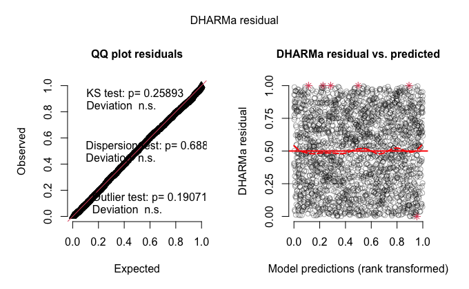

```r
plot(sim_res)
```

```
    DHARMa nonparametric dispersion test via sd of residuals fitted vs. simulated

data:  simulationOutput
dispersion = 0.5332, p-value = 0.688
alternative hypothesis: two.sided
```

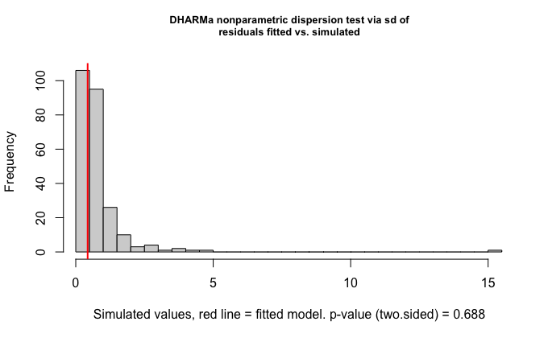

```r
testDispersion(sim_res)
```

```
    DHARMa zero-inflation test via comparison to expected zeros with simulation under H0 = fitted
    model

data:  simulationOutput
ratioObsSim = 0.96648, p-value = 0.96
alternative hypothesis: two.sided
```

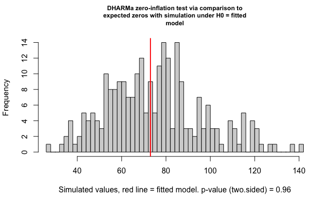

```r
testZeroInflation(sim_res)
```

```
    DHARMa nonparametric dispersion test via sd of residuals fitted vs. simulated

data:  simulationOutput
dispersion = 0.5332, p-value = 0.688
alternative hypothesis: two.sided
```

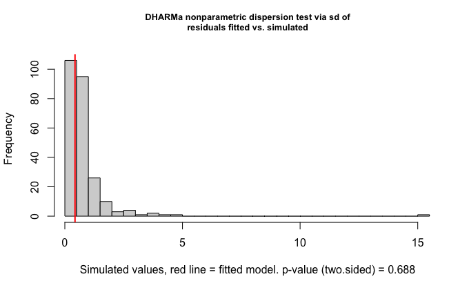

```r
testDispersion(sim_res)
```

```
    DHARMa zero-inflation test via comparison to expected zeros with simulation under H0 = fitted
    model

data:  simulationOutput
ratioObsSim = 0.96648, p-value = 0.96
alternative hypothesis: two.sided
```

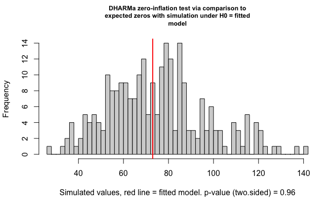

```r
testZeroInflation(sim_res)
```

```r
ranef(m_final)
```

```
$City
            (Intercept) Green_area_coverage
Barcelona    0.30818104        -0.002655854
Casablanca  -0.33238998         0.006394240
Montpellier -0.28390851         0.009413326
Nijmegen    -0.08112456         0.001689374
Rabat       -0.19013724         0.003748720
Utrecht      0.57937924        -0.018589807

$`Location.Site:City`
               (Intercept)
1:Barcelona    0.095847253
1:Casablanca  -0.243451572
1:Montpellier  0.151656737
1:Nijmegen    -0.273655098
1:Rabat       -0.272023362
1:Utrecht      0.110152798
2:Barcelona   -0.183044292
2:Casablanca   0.207787347
2:Montpellier -0.121132405
2:Nijmegen     0.213752885
2:Rabat        0.131843872
2:Utrecht     -0.017698950
3:Barcelona   -0.263666283
3:Casablanca   0.013892198
3:Montpellier  0.361470013
3:Nijmegen    -0.136765388
3:Rabat       -0.414990608
3:Utrecht     -0.154518243
4:Barcelona    0.290452006
4:Casablanca   0.018444863
4:Montpellier -0.071623654
4:Nijmegen     0.108653011
4:Rabat        0.151604972
4:Utrecht     -0.278429810
5:Barcelona    0.106999146
5:Casablanca  -0.141538724
5:Montpellier  0.245087248
5:Nijmegen    -0.334880381
5:Rabat       -0.307865899
```

[output cut: 18 more lines]

```
8:Utrecht      0.256644028
9:Barcelona    0.241075634
9:Casablanca  -0.262734516
9:Montpellier  0.066594218
9:Nijmegen    -0.481648415
9:Rabat        0.039525185
9:Utrecht      0.030173662

$Mosquito_species
                        (Intercept)
Aedes aegypti           0.497368608
Aedes albopictus       -0.389166668
Anopheles gambiae       0.196409201
Culex pipiens          -0.001869955
Culex quinquefasciatus -0.302741185
```

## 5. Model Interpretation

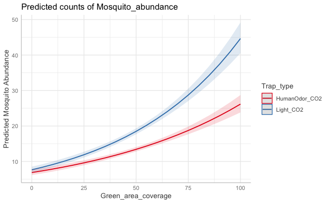

```r
preds <- ggpredict(m_final, terms = c("Green_area_coverage", "Trap_type"))
plot(preds) + labs(y="Predicted Mosquito Abundance")
```

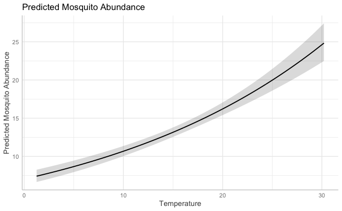

```r
pred_temp <- ggpredict(m_final, terms = "Temperature [all]")
plot(pred_temp) +
  labs(title = "Predicted Mosquito Abundance",
       y="Predicted Mosquito Abundance")
```

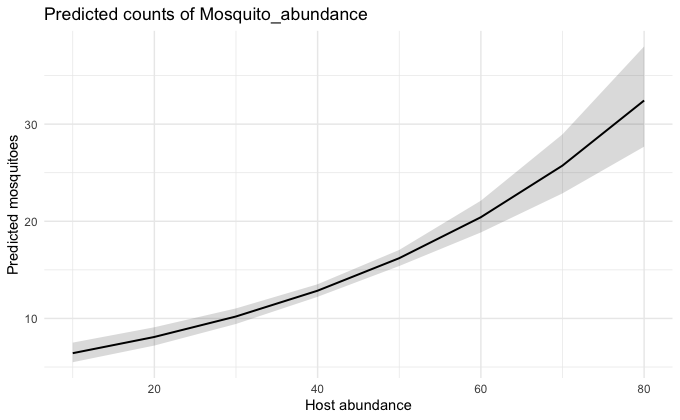

```r
pred_host <- ggpredict(m_final, terms = "Host_abundance")
plot(pred_host) +
  labs(x="Host abundance", y="Predicted mosquitoes") +
  theme_minimal()
```

```r
NA
NA
```

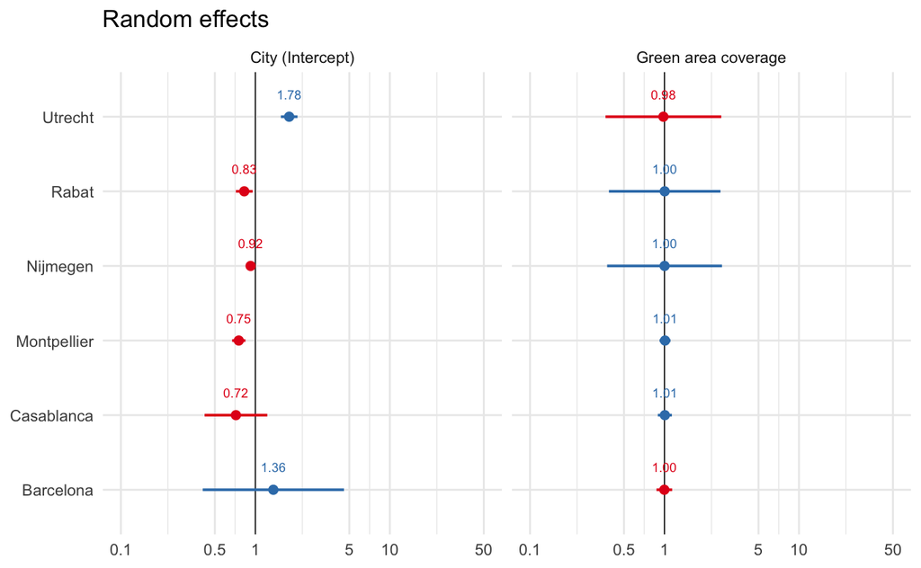

```r
replot_city <- sjPlot::plot_model(
  m_final, type = "re",
  show.values  = TRUE,
  value.offset = 0.3,
  value.size   = 2.5,
  dot.size     = 2,
  line.size    = 0.7,
  vline.color  = "black"
)[[1]] +
  theme_minimal()

replot_city$facet$params$labeller <- labeller(.default = function(x) gsub("_", " ", x))

replot_species <- sjPlot::plot_model(m_final, type = "re",
                              show.values = TRUE,
                              value.offset = 0.3,
                              value.size = 2.5,
                              dot.size = 2,
                              line.size = 0.7,
                              vline.color = 'black')[[3]] + theme_minimal()
replot_city
```

```r
replot_species

ggsave(
  filename = "random_effects_city.png",
  plot     = replot_city,
  path = "./Simulated Data/",
  width    = 6,
  height   = 4,
  dpi      = 300
)
```

[figure not shown]

```r
ggsave(
  filename = "random_effects_species.png",
  plot     = replot_species,
  path = "./Simulated Data/",
  width    = 6,
  height   = 4,
  dpi      = 300
)
```

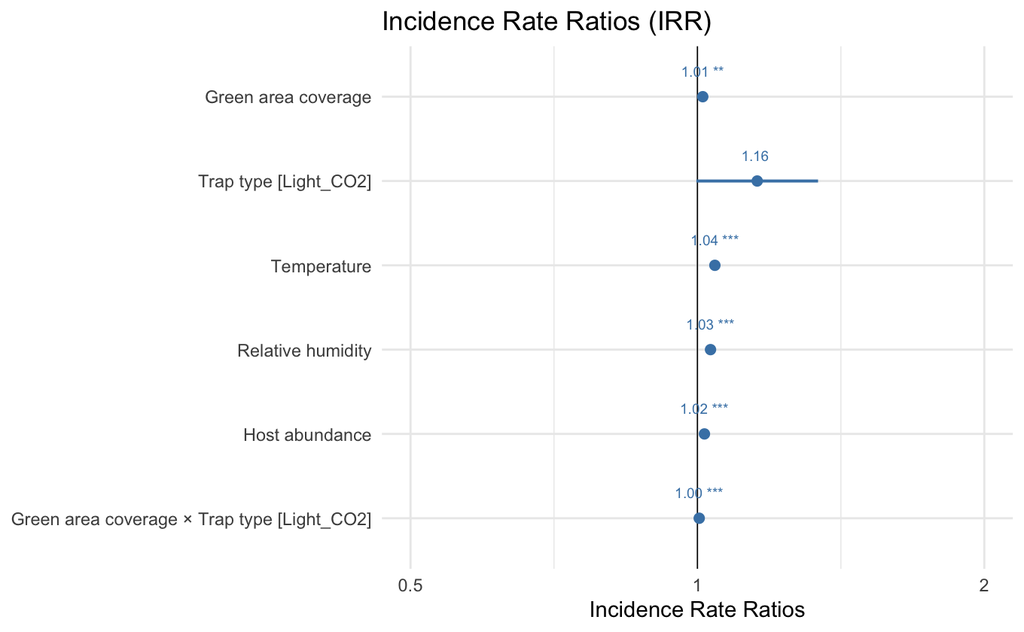

```r
p <- sjPlot::plot_model(m_final, type = "est", transform = "exp",
                axis.lim = c(0.8, 1.4),
                show.values = TRUE,
                value.offset = 0.3,
                value.size = 2.5,
                dot.size = 2,
                line.size = 0.7,
                vline.color = 'black') +
  labs(title = "Incidence Rate Ratios (IRR)") +
  theme_minimal() + scale_color_manual(values = c("steelblue"))

p

ggsave(
  filename = "irr_plot.png",
  plot     = p,
  path = "./Simulated Data/",
  width    = 6,
  height   = 4,
  dpi      = 300
)
```

```r
icc_values <- performance::icc(m_final, tolerance = 1e-6)
icc_values
```

```
# Intraclass Correlation Coefficient

    Adjusted ICC: 0.436
  Unadjusted ICC: 0.300
```